# Impact of Adult Health-Related Practices on Juvenile Health Outcomes

Authors

Brooke Benton

Rohan Devraj

Jade Kay

Jessica Lambert

Published

July 26, 2024

## Introduction

The health behaviors of adults in a community can have a profound impact on their children’s health outcomes. Juvenile quality and length of life can be impacted by the behaviors of the adults around them, such as smoking, drinking, poor diet, and physical inactivity. More insight into the relationship between these variables can be used to identify intergenerational health impacts to provide early intervention and prevention of juvenile outcomes, as well as inform new policy and education. In this report, we analyze the impact of a variety of adult health behaviors on child mortality rate and low birthweight on a county level.

We decided to use low birthweight as a measure of juvenile outcomes due to the risk of future health complications and death. According to the original data source, “infants born with low birthweight have approximately 20 times greater chance of dying than those with normal birth weight” (County Health Rankings 2024). Moreover, infants who survive low birthweight at birth “may face adverse health outcomes such as decreased growth, lower IQ, impaired language development, and chronic conditions (e.g., obesity, diabetes, cardiovascular disease) during adulthood” (County Health Rankings 2024). We also chose to use the child mortality rate variable as a juvenile outcome- while childhood mortality is somewhat rare, mortality rates illustrate the most severe consequence of negative health behaviors and can point to the most significant behaviors that need to be addressed.

## The Data

The data utilized is from the County Health Rankings & Roadmaps sourced by the Population Health Institute at the University of Washington. This dataset includes health and socioeconomic data at county level across the United States from 2024. Our key juvenile health outcomes, child mortality rate and low birthweight, are measured as number of deaths among residents under age 20 per 100,000 population and percentage of live births less than 2,500 grams, respectively. For this report we focused primarily on the following adult health behaviors and environments.

- Insufficient sleep: percentage of adults who report fewer than 7 hours of sleep on average
- Excessive drinking: percentage of adults reporting binge or heavy drinking
- Adult smoking: percentage of adults who are current smokers
- Food Insecurity: percentage of adults who lack adequate access to food
- Uninsured: percentage of adult population under age 65 without health insurance
- Sexually Transmitted Infections: number of newly diagnosed chlamydia cases per 100,000 population
- Physical Inactivity: percentage of adults reporting no leisure-time physical activity
- Adult Obesity: percentage of the adult population that reports a body mass index greater than or equal to 30 kg/m2

## Exploratory Data Analysis & Cleaning

We performed some initial pre-processing and cleaning of the dataset before investigating the variables. The following scatterplots demonstrate the child mortality rate relationship between adult obesity, adult smoking, and excessive drinking. Excessive drinking seems to contribute to the least amount of child mortality. However, adult smoking and adult obesity are able to show an increase in percentage as it relates to an increase in child mortality. From this we can predict that adult obesity and adult smoking has the highest correlation towards child mortality. Moreover, adult smoking and child mortality have the highest correlation coefficient which is 0.58.

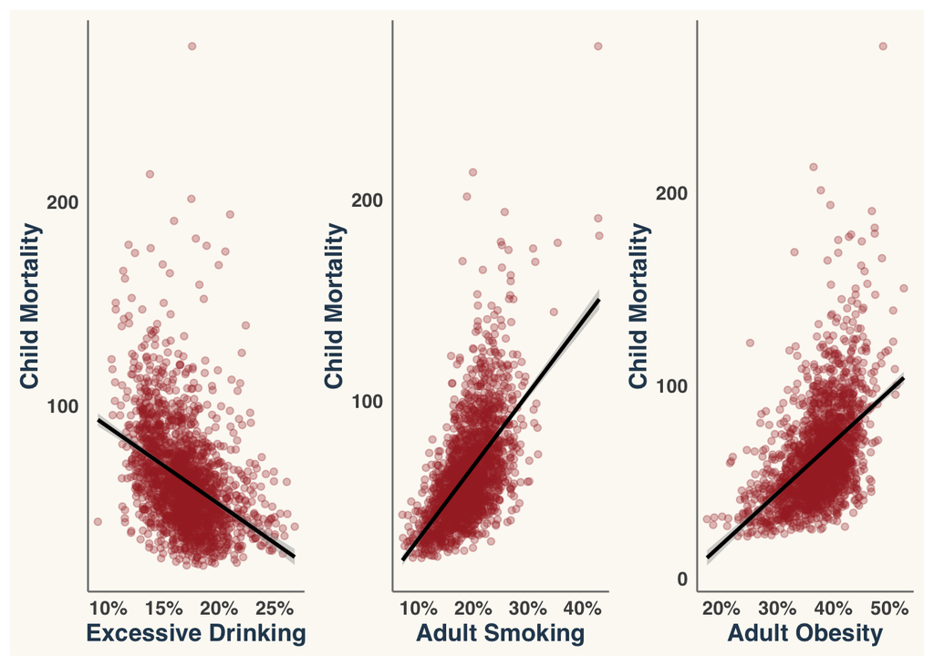

Figure 1: Displays the relationships between child mortality and excessive drinking, adult smoking, and adult obesity at each county

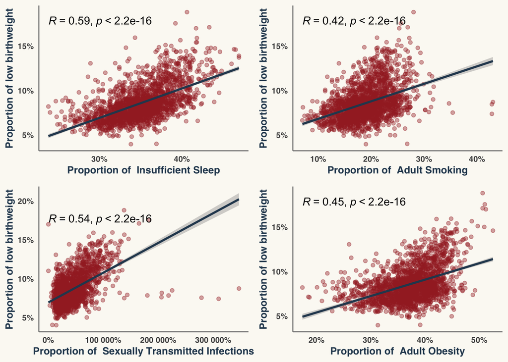

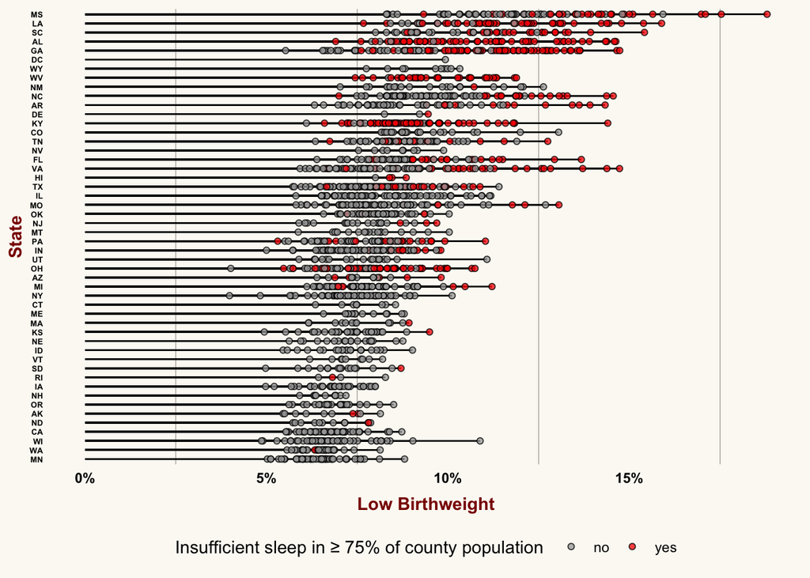

## Methods and Results

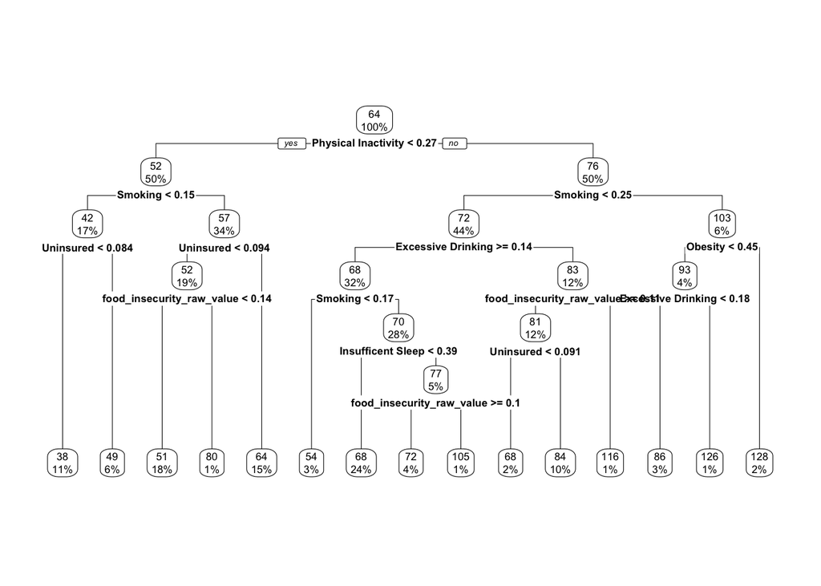

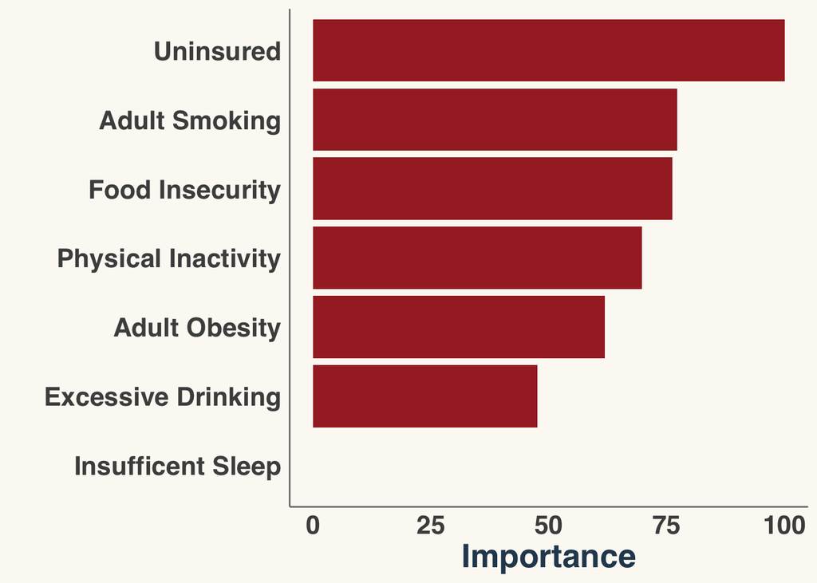

## Discussion

In this report, we examined a multitude of adult health behaviors and their relationship to child mortality and low birthweight.

**Limitations**

The dataset only included three variables specific to juvenile health, two of which we chose to focus on. Child mortality rate is a relatively rare event and will experience small changes, especially in small communities, which may be hard to detect. Counties with smaller populations may also experience a lot of relative change in mortality rates from year to year, often due to normal variation rather than the true underlying risk for child mortality. The dataset consisted of county level population data, rather than data on parent-to-child relationships. This limited the conclusions we could make from trends in the data.

**Future Work**

Based on our research for future studies, using demographic, income, and gender can all be contributing variables as it pertains to the outcome of low birthweight and child mortality. Having variables categorized by age can contribute to a bigger significance towards variables used. Age can give a further look into which age group has the highest correlation towards the variables used.

## Appendix

### Code blocks

[output not shown]

Chunk options can also be written inside the code block, which is helpful for really long options, as we’ll see soon.

[output not shown]

### Figures

If a code block produces a plot or figure, this figure will automatically be inserted inline in the report. That is, it will be inserted exactly where the code block is.

[figure not shown]

Notice the use of `fig-width` and `fig-height` to control the figure’s size (in inches). These control the sizes given to `R` when it generates the plot, so `R` proportionally adjusts the font sizes to be large enough.

### Tables

Use the `knitr::kable()` function to print tables as HTML:

[output not shown]

We can summarize model results with a table. For instance, suppose we fit a linear regression model:

```r
model1 <- lm(mpg ~ disp + hp + drat, data = mtcars)
```

It is *not* appropriate to simply print `summary(model1)` into the report. If we want the reader to understand what models we have fit and what their results are, we should provide a nicely formatted table. A simple option is to use the `tidy()` function from the `broom` package to get a data frame of the model fit, and simply report that as a table.

Predicting fuel economy using vehicle features.

[output not shown]